# Fetching and analyzing grunnkart for arealregnskap

Author

Jens Åström

```r
suppressPackageStartupMessages({
  library(NinaR)
  library(sf)
  library(dplyr)
  library(ggplot2)
  library(landscapemetrics)
  library(terra)
})
```

```r
postgreSQLConnect()
```

## Create a small test set of vectors to fetch grunnkarts-info for.

```r
small_sf <- tibble(locality = c("Semi-nat_99", "Semi-nat_100"), geom = c("POLYGON ((1082500 7775000, 1082500 7775500, 1083000 7775500, 1083000 7775000, 1082500 7775000))", "POLYGON ((1019000 7842500, 1019000 7843000, 1019500 7843000, 1019500 7842500, 1019000 7842500))")) |>
  st_as_sf(wkt = "geom", crs = 25833)
```

Fetch grunnkart data for these areas. !N.B. that the areas in areal_m2 is recalculated by default after clipping. If you want the original areas (of the unclipped geometries), set recalculate_areas = FALSE.

```r
small_sf_grunnkart <- clip_gis_layer(small_sf)
```

```r
small_sf_grunnkart
```

```
Simple feature collection with 86 features and 19 fields
Geometry type: GEOMETRY
Dimension:     XY
Bounding box:  xmin: 1019000 ymin: 7775000 xmax: 1083000 ymax: 7843000
Projected CRS: ETRS89 / UTM zone 33N
# A tibble: 86 × 20
   locality     ogc_fid arealdekke         treslag      skogbonitet grunnforhold
 * <chr>          <int> <chr>              <chr>        <chr>       <chr>
 1 Semi-nat_99 19180461 Myr_aapen          Ikke_releva… Ikke_relev… Organisk_jo…
 2 Semi-nat_99 18702324 Skog               Lauv         Lav_bonitet Jorddekt
 3 Semi-nat_99 18721901 Skog               Lauv         Middels_bo… Organisk_jo…
 4 Semi-nat_99 18884626 Bebygd             Ikke_releva… Ikke_relev… Ikke_releva…
 5 Semi-nat_99 18884627 Bebygd             Ikke_releva… Ikke_relev… Ikke_releva…
 6 Semi-nat_99 19138340 Jordbruk_fulldyrka Ikke_releva… Ikke_relev… Organisk_jo…
 7 Semi-nat_99 19233192 Samferdsel         Ikke_releva… Ikke_relev… Ikke_releva…
 8 Semi-nat_99 19292033 Samferdsel         Ikke_releva… Ikke_relev… Ikke_releva…
 9 Semi-nat_99 19347709 Samferdsel         Ikke_releva… Ikke_relev… Ikke_releva…
10 Semi-nat_99 19347711 Samferdsel         Ikke_releva… Ikke_relev… Ikke_releva…
# ℹ 76 more rows
# ℹ 14 more variables: arealbruk_hovedklasse <chr>,
#   arealbruk_underklasse <chr>, havarealbrukstedbundet <chr>,
#   havfiskeribruk <chr>, okosystemtype_1 <chr>, okosystemtype_2 <chr>,
#   okosystemtype_3 <chr>, okosystemtype_kode <chr>, grunnkart_kilde <chr>,
#   ssbarealbruk_kilde <chr>, komid <int>, areal_m2 [m^2],
#   geom_original <pq_gmtry>, geom <GEOMETRY [m]>
```

Plot one of the areas. In these examples, we use ‘ekosystemtype_1’ as the main feature to analyze, but you could choose any other as well.

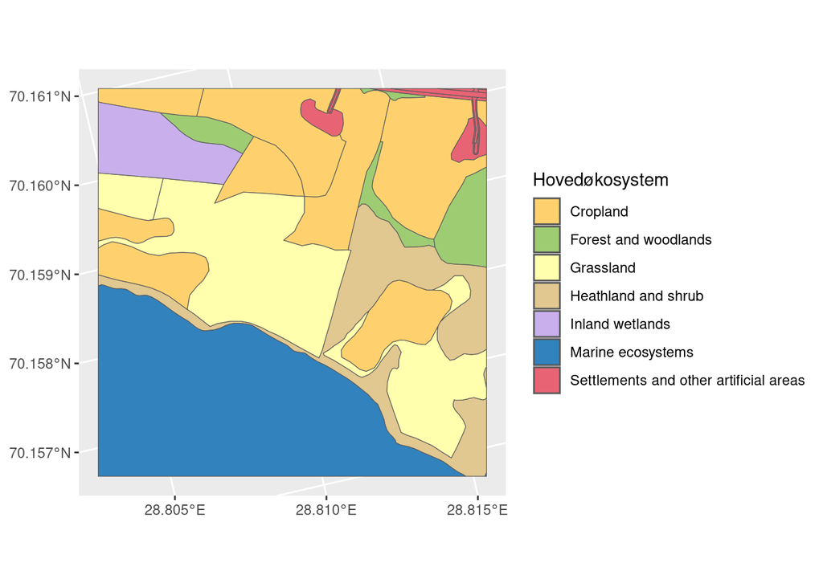

Figure 1: Ecosystem level 1 for clipped polygon

```r
small_sf_grunnkart |>
  filter(locality == "Semi-nat_100") |>
  ggplot() +
  geom_sf(aes(fill = okosystemtype_1)) +
  scale_fill_okosystemtype_1(name = "Hovedøkosystem")
```

Notice we use a custom ggplot fill function for okoystemtype_1. You can plot arealdekke in a similar way. Other color scale functions might be added later on.

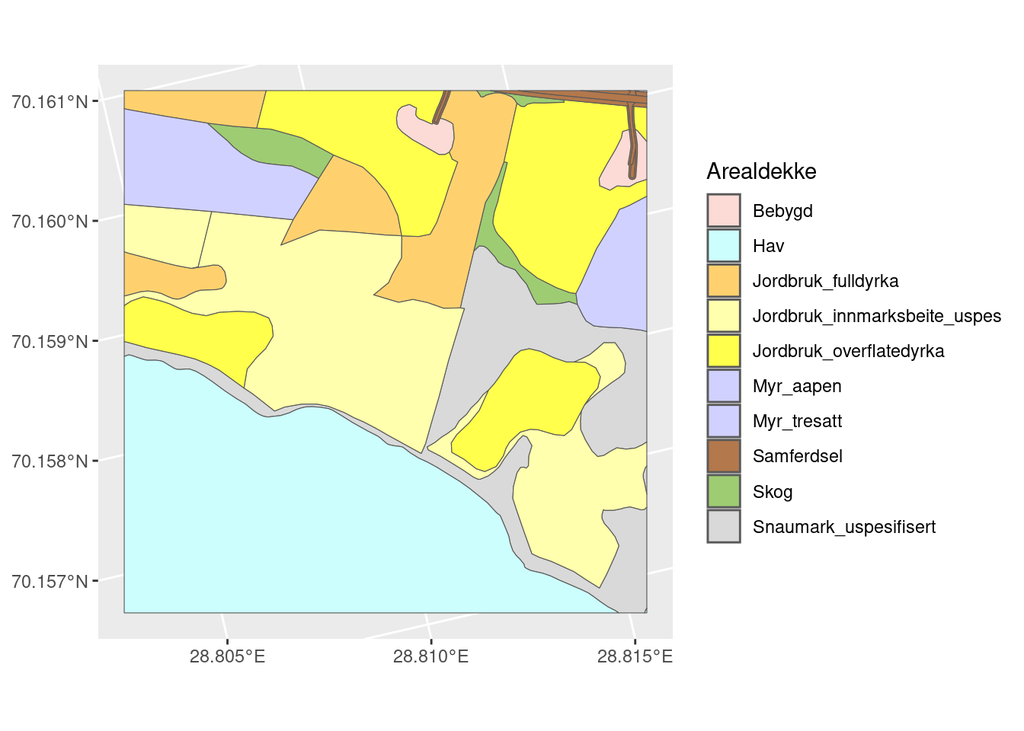

Figure 2: Arealdekke for clipped polygon

```r
small_sf_grunnkart |>
  filter(locality == "Semi-nat_100") |>
  ggplot() +
  geom_sf(aes(fill = arealdekke)) +
  scale_fill_arealdekke(name = "Arealdekke")
```

Optionally, instead of clipping the geometries, you can get the whole geometries that intersects with the masking / clipping layer. This is perhaps most useful when masking / clipping with point geometries (such as points of species occurrences).

```r
sample_point <- tibble(locality = "Point_1", geom = "POINT (1082550 7775050)") |>
  st_as_sf(wkt = "geom", crs = 25833)

small_sf_grunnkart_not_clipped <- clip_gis_layer(sample_point,
                                                 clip_geometries = FALSE)
```

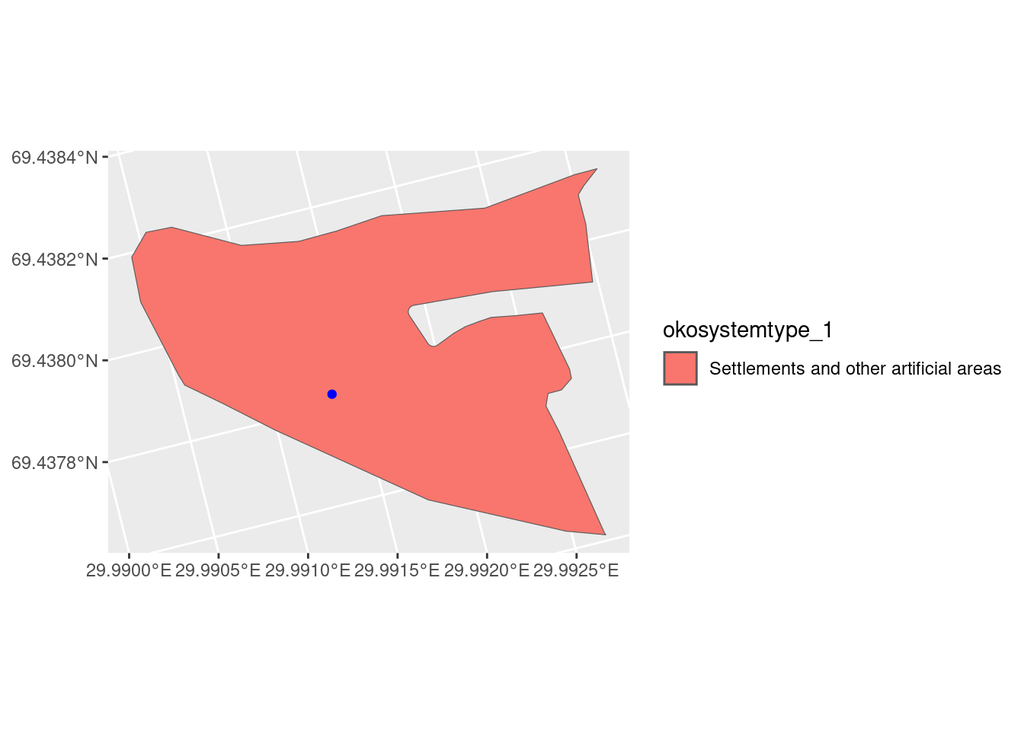

Figure 3: Fetched grunnkart which overlaps with a point

```r
small_sf_grunnkart_not_clipped |>
  ggplot() +
  geom_sf(aes(fill = okosystemtype_1)) +
  geom_sf(color = "blue", data = sample_point)
```

## Aggregating data

The grunnkart often has several connecting geometries of the same type. We can aggregate (union) them to get simpler geometries, if we prefer. If you do this, you have to decide what feature to join on, and you throw away the alternative features in the grunnkart.

```r
small_sf_grunnkart_union <- union_gis_layer(small_sf_grunnkart,
  column_to_join_on = "okosystemtype_1"
)
```

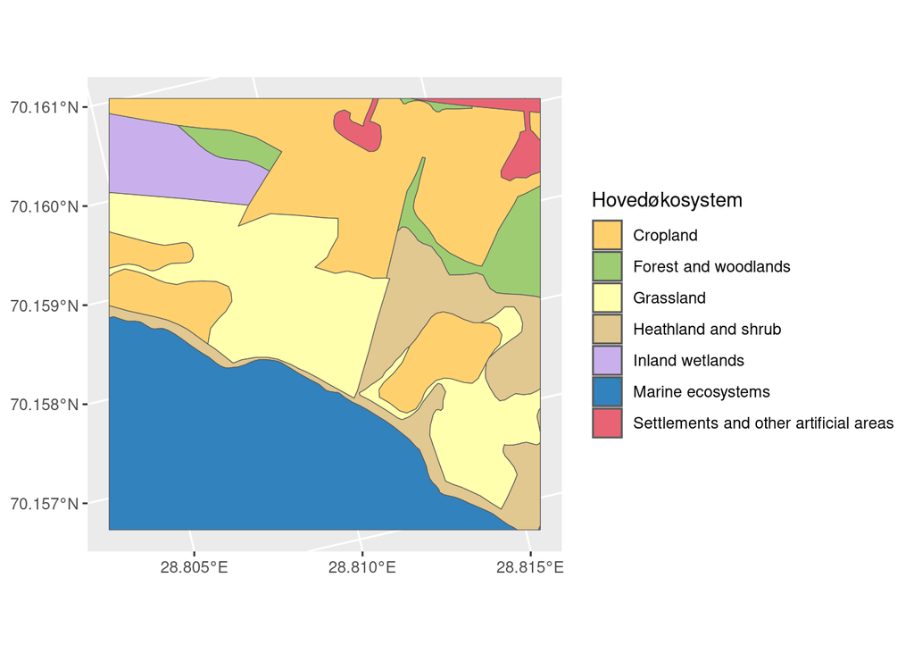

Figure 4: The same ecosystem level 1 after unioning similar adjoining geometries.

```r
small_sf_grunnkart_union |>
  filter(locality == "Semi-nat_100") |>
  ggplot() +
  geom_sf(aes(fill = okosystemtype_1)) +
  scale_fill_okosystemtype_1(name = "Hovedøkosystem")
```

Areal statistics is easy enough to calculate with normal tidyverse functions. By default, the `clip_gis_layer` function recalculates the areas in the areal_m2 column, so you should be able to use these. However, this can be cumbersome in practise, as you have to calculate areas in several grouping steps, and reattach geometries etc.

It is easier to use the unioned sf-object like this:

```r
small_sf_grunnkart_union <- small_sf_grunnkart_union |>
  mutate(area_m2 = st_area(geom)) |>
  group_by(locality) |>
  mutate(percentage_area = area_m2 / sum(area_m2) * 100)
```

```r
small_sf_grunnkart_union
```

```
Simple feature collection with 12 features and 4 fields
Geometry type: GEOMETRY
Dimension:     XY
Bounding box:  xmin: 1019000 ymin: 7775000 xmax: 1083000 ymax: 7843000
Projected CRS: ETRS89 / UTM zone 33N
# A tibble: 12 × 5
# Groups:   locality [2]
   locality    okosystemtype_1                      geom area_m2 percentage_area
 * <chr>       <chr>                      <GEOMETRY [m]>   [m^2]             [1]
 1 Semi-nat_1… Cropland        MULTIPOLYGON (((1019388 …  69400.          27.8
 2 Semi-nat_1… Forest and woo… MULTIPOLYGON (((1019476 …  11628.           4.65
 3 Semi-nat_1… Grassland       MULTIPOLYGON (((1019484 …  53481.          21.4
 4 Semi-nat_1… Heathland and … MULTIPOLYGON (((1019000 …  27802.          11.1
 5 Semi-nat_1… Inland wetlands POLYGON ((1019000 784298…  12511.           5.00
 6 Semi-nat_1… Marine ecosyst… MULTIPOLYGON (((1019000 …  70217.          28.1
 7 Semi-nat_1… Settlements an… MULTIPOLYGON (((1019491 …   4961.           1.98
 8 Semi-nat_99 Cropland        MULTIPOLYGON (((1082946 …  82740.          33.1
 9 Semi-nat_99 Forest and woo… MULTIPOLYGON (((1082503 … 132430.          53.0
10 Semi-nat_99 Heathland and … MULTIPOLYGON (((1082789 …   1927.           0.771
11 Semi-nat_99 Inland wetlands MULTIPOLYGON (((1082502 …  17299.           6.92
12 Semi-nat_99 Settlements an… MULTIPOLYGON (((1082501 …  15605.           6.24
```

Note that if you haven’t unioned similar features within the locality / buffer, you have to group by locality and okosystemtype_1 and use ‘sum(st_area(geom))’ in the first step to get a single area for each okosystem type within a locality.

## Other layers - Buildings example

We can use the same function to clip other layers in the database, if we specify the schema (if needed) and the layer name. Buildings can be a popular layer to combine with the arealkart for example.

```r
small_sf_buildings <- clip_gis_layer(small_sf,
                                     schema = "buildings",
                                     layer_to_clip = "fkb_bygning_omrade")
```

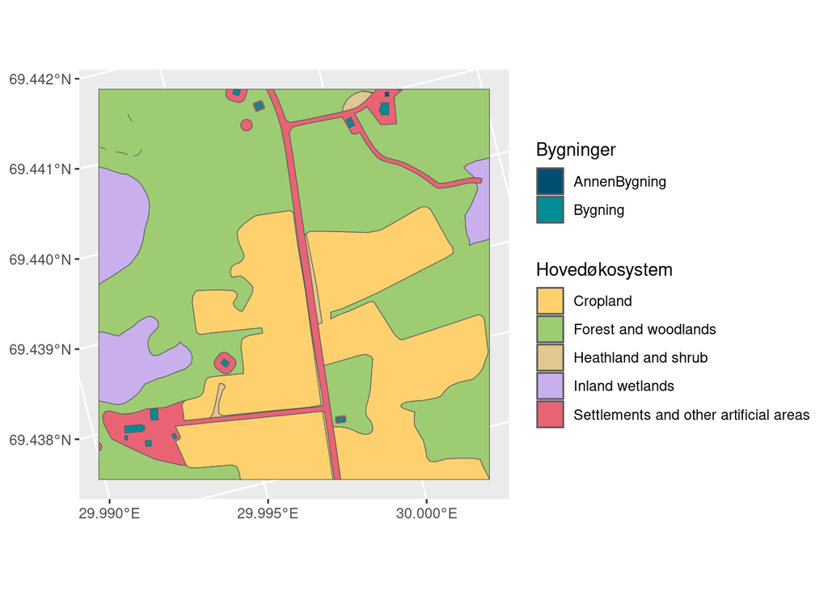

```r
small_sf_buildings_99 <- small_sf_buildings |>
  filter(locality == "Semi-nat_99")

p <- small_sf_grunnkart_union |>
    filter(locality == "Semi-nat_99") |>
    ggplot() +
    geom_sf(aes(fill = okosystemtype_1)) +
    scale_fill_okosystemtype_1(name = "Hovedøkosystem")

p <- p + ggnewscale::new_scale_fill() +
  geom_sf(aes(fill = objtype), data = small_sf_buildings_99) +
  scale_fill_nina(name = "Bygninger")

p
```

## Rasterizing

We can rasterize these vectors, to be able to use the package landscapemetrics, for example to calculate the shannon diversity of the ecosystem types in the localities. Here we provide just the resolution for the raster, but you could also provide a reference raster layer as a template.

```r
grunnkart_raster <- rasterize_gis_layer(small_sf_grunnkart_union,
                                        feature_column = "okosystemtype_1",
                                        resolution = 10
                                        )
```

We can visualize the results, here done quickly with base R plotting functions.

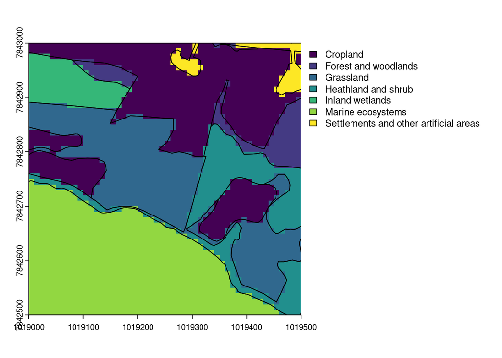

Figure 6: Ecosystem type 1 after rasterization to 10x10 m resolution.

```r
temp_v <- small_sf_grunnkart_union |> filter(locality == "Semi-nat_100") |> vect()
temp_r <- grunnkart_raster["Semi-nat_100"][[1]]

plot(temp_r, mar=c(2, 2, 2, 14))
lines(temp_v)
```

We can for example calculate the shannon index of the ecosystemtype_1 variants within each locality / area.

```r
grunnkart_raster_shannon_index <- lsm_l_shdi(grunnkart_raster)
grunnkart_raster_shannon_index$layer <- names(grunnkart_raster)

locality_okosystemtype_1_shdi <- grunnkart_raster_shannon_index %>%
  dplyr::select(
    locality = layer,
    lsm_l_shdi = value
  )

locality_okosystemtype_1_shdi
```

```
# A tibble: 2 × 2
  locality     lsm_l_shdi
  <chr>             <dbl>
1 Semi-nat_100       1.66
2 Semi-nat_99        1.10
```

## Another example with a gpg file stored locally

```r
solar_raw <- read_sf("../temp/solar_polygons.gpkg")
solar_raw
```

```
Simple feature collection with 49 features and 21 fields
Geometry type: MULTIPOLYGON
Dimension:     XY
Bounding box:  xmin: -38980.32 ymin: 6470501 xmax: 344548.4 ymax: 6841153
Projected CRS: ETRS89 / UTM zone 33N
# A tibble: 49 × 22
   OBJECTID objektType   anleggsNr saksID anleggNavn    eier  stadium saksKatego
      <dbl> <chr>            <dbl>  <dbl> <chr>         <chr> <chr>        <dbl>
 1    17511 Solkraftverk     14408  16129 Glamsland so… GREE… Søknad           1
 2    17526 Solkraftverk     14545  14040 Løvbergsmoen… NØK … Utredn…          1
 3    17528 Solkraftverk     13711  12966 Kile solkraf… GUDB… Konses…          2
 4    17529 Solkraftverk     14425  16111 Fossum solkr… FOSS… Høring           1
 5    17530 Solkraftverk     14425  16111 Fossum solkr… FOSS… Høring           1
 6    17531 Solkraftverk     14559   7618 Furuseth sol… SOLG… Konses…          2
 7    17532 Solkraftverk     14177  16119 Slåtta solkr… GREE… Søknad           1
 8    17533 Solkraftverk     13876  14039 Simonstad so… FRED… Utredn…          1
 9    17534 Solkraftverk     14161  16107 Lista solkra… FRED… Meldin…          4
10    17535 Solkraftverk     13876  14039 Simonstad so… FRED… Utredn…          1
# ℹ 39 more rows
# ℹ 14 more variables: lokaliseri <chr>, saksLenke <chr>, kommune <chr>,
#   fylkeNavn <chr>, status <chr>, datafangst <dbl>, malemetode <dbl>,
#   noyaktighe <dbl>, objektStat <dbl>, objektSt01 <dbl>, GlobalID <chr>,
#   Shape_Leng <dbl>, Shape_Area <dbl>, geom <MULTIPOLYGON [m]>
```

```r
solar_clip <- clip_gis_layer(solar_raw,
                             clip_geometries = T)
solar_clip
```

```
Simple feature collection with 1464 features and 19 fields
Geometry type: GEOMETRY
Dimension:     XY
Bounding box:  xmin: -38980.32 ymin: 6470501 xmax: 344548.4 ymax: 6841153
Projected CRS: ETRS89 / UTM zone 33N
# A tibble: 1,464 × 20
   OBJECTID  ogc_fid arealdekke             treslag     skogbonitet grunnforhold
 *    <dbl>    <int> <chr>                  <chr>       <chr>       <chr>
 1    17511 14375467 Snaumark_uspesifisert  Ikke_relev… Ikke_relev… Jorddekt
 2    17511 14919573 Samferdsel             Ikke_relev… Ikke_relev… Ikke_releva…
 3    17511 14859581 Samferdsel             Ikke_relev… Ikke_relev… Ikke_releva…
 4    17511 14357153 Samferdsel             Ikke_relev… Ikke_relev… Ikke_releva…
 5    17511 14358807 Samferdsel             Ikke_relev… Ikke_relev… Ikke_releva…
 6    17511 14352632 Ferskvann_innsjo_tjern Ikke_relev… Ikke_relev… Ikke_releva…
 7    17511 14434555 Bebygd                 Ikke_relev… Ikke_relev… Ikke_releva…
 8    17511 14877550 Samferdsel             Ikke_relev… Ikke_relev… Ikke_releva…
 9    17511 14969459 Snaumark_uspesifisert  Ikke_relev… Ikke_relev… Jorddekt
10    17511 15187461 Skog                   Furu        Impediment  Grunnlendt
# ℹ 1,454 more rows
# ℹ 14 more variables: arealbruk_hovedklasse <chr>,
#   arealbruk_underklasse <chr>, havarealbrukstedbundet <chr>,
#   havfiskeribruk <chr>, okosystemtype_1 <chr>, okosystemtype_2 <chr>,
#   okosystemtype_3 <chr>, okosystemtype_kode <chr>, grunnkart_kilde <chr>,
#   ssbarealbruk_kilde <chr>, komid <int>, areal_m2 [m^2],
#   geom_original <pq_gmtry>, geom <GEOMETRY [m]>
```

```r
solar_clip_unioned <- union_gis_layer(solar_clip,
                                      column_to_join_on = "okosystemtype_1",
                                      id_column = "OBJECTID")
```

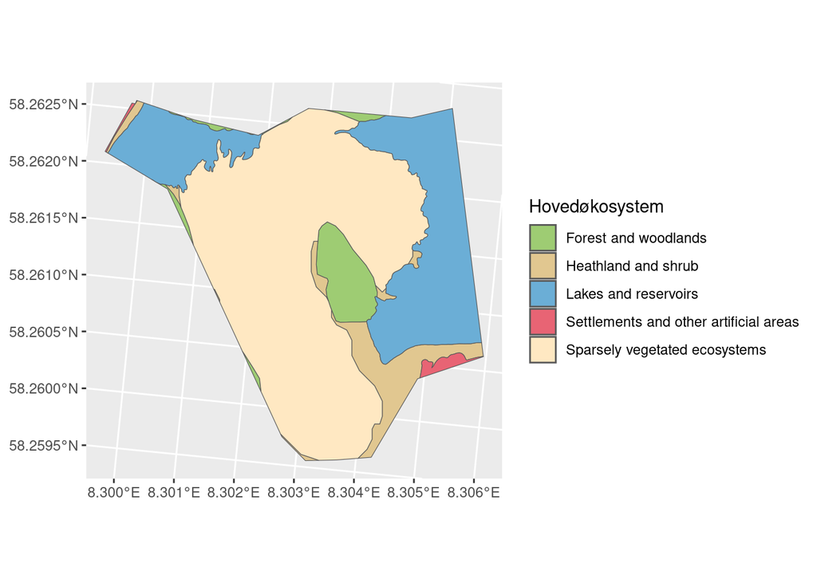

Figure 7: Ecosystem type 1 for a clipping layer made from a gpkg-file.

```r
solar_clip_unioned |>
  filter(OBJECTID == '17511') |>
    ggplot() +
  geom_sf(aes(fill = okosystemtype_1)) +
  scale_fill_okosystemtype_1(name = "Hovedøkosystem")
```